# ESE5023_Assignment03_12132834

## CAO Zhe (曹喆)'s TA report for assignment03

## SID: 12132834

## Github: https://github.com/kedaobilianxu/ESE5023_Assignments_12132834

## Responsible TA: HUANG Hao

## Grade: 47

## 1. Niño 3.4 index (10/10)

The Niño 3.4 anomalies may be thought of as representing the average equatorial sea surface temperatures (SSTs) across the Pacific from about the dateline to the South American coast (5N-5S, 170W-120W). The Niño 3.4 index typically uses a 3-month running mean, and El Niño or La Niña events are defined when the Niño 3.4 SSTs exceed +/- 0.5°C for a period of 5 months or more. Check Equatorial Pacific Sea Surface Temperatures for more about the Niño 3.4 index.

In this problem set, you will use the sea surface temperature (SST) data from NOAA. Download the netCDF4 file (NOAA_NCDC_ERSST_v3b_SST.nc) here.</font>

**1.1 [5 points] Compute monthly climatology for SST from Niño 3.4 region, and subtract climatology from SST time series to obtain anomalies.**

**首先根据经纬度截取nino3.4地区的数据，再求出anoma值**

```python
import numpy as np
import pandas as pd
import xarray as xr
from matplotlib import pyplot as plt
ds = xr.open_dataset('C:\\Users\\Cao Zhe\\Desktop\\sustech zy\\hjbc\\PS3\\NOAA_NCDC_ERSST_v3b_SST.nc', engine="netcdf4")
ds_nino = ds.sst.sel(lat = slice(-5,5),lon = slice(190,240))#截取nino3.4地区的数据
ds_nino_month_avar = ds_nino.groupby('time.month').mean(dim = ['time','lat','lon'])
ds_nino_avar = ds_nino.mean(dim = ['lat','lon'])
ds_nino_anoma = ds_nino_avar.groupby('time.month') - ds_nino_month_avar
print(ds_nino_anoma)
```

[output not shown]

[output cut: 37 more lines]

[output not shown]

```python
import numpy as np
import pandas as pd
import xarray as xr
from matplotlib import pyplot as plt
ds = xr.open_dataset('NOAA_NCDC_ERSST_v3b_SST.nc', engine="netcdf4")
ds_nino = ds.sst.sel(lat = slice(-5,5),lon = slice(190,240))#截取nino3.4地区的数据
ds_nino_month_avar = ds_nino.groupby('time.month').mean(dim = ['time','lat','lon'])
ds_nino_avar = ds_nino.mean(dim = ['lat','lon'])
ds_nino_anoma = ds_nino_avar.groupby('time.month') - ds_nino_month_avar
print(ds_nino_anoma)
```

```
<xarray.DataArray 'sst' (time: 684)>
array([-3.19580078e-01, -4.68521118e-01, -2.68152237e-01, -1.86967850e-01,
       -1.77595139e-01, -3.57690811e-01, -1.41971588e-01,  1.46579742e-02,
       -1.52215958e-01, -3.79865646e-01, -3.60893250e-01, -2.08696365e-01,
       -1.91473007e-01, -1.34283066e-01, -2.40375519e-01, -1.85127258e-01,
        5.19180298e-02,  2.39383698e-01, -7.03411102e-02, -4.18693542e-01,
       -7.78314590e-01, -7.92385101e-01, -4.96292114e-01, -4.17310715e-01,
       -4.44782257e-01, -4.55940247e-01, -4.36033249e-01, -4.66928482e-01,
       -5.64529419e-01, -4.26885605e-01, -2.76727676e-01, -3.17211151e-01,
       -6.73158646e-01, -6.66118622e-01, -8.17707062e-01, -8.65486145e-01,
       -7.01400757e-01, -3.57038498e-01,  6.96258545e-02,  1.73398972e-01,
       -9.06677246e-02,  7.69157410e-02,  6.87639236e-01,  7.95261383e-01,
        7.12980270e-01,  8.34249496e-01,  9.08538818e-01,  1.08588600e+00,
        8.51554871e-01,  5.23397446e-01, -1.30540848e-01, -6.34365082e-01,
       -8.61980438e-01, -9.45945740e-01, -7.84177780e-01, -1.09434509e+00,
       -1.25451469e+00, -1.18983650e+00, -1.29195786e+00, -1.20479584e+00,
       -7.82999039e-01, -3.68686676e-01, -1.12600327e-01, -7.66315460e-02,
        2.68377304e-01,  5.91150284e-01,  8.12011719e-01,  1.23806953e+00,
        1.27759743e+00,  1.52435303e+00,  1.58320427e+00,  1.44118118e+00,
        1.17595100e+00,  9.12748337e-01,  9.74021912e-01,  5.48080444e-01,
       -1.27164841e-01,  1.68796539e-01,  2.07979202e-01, -1.75546646e-01,
...
       -1.43000031e+00, -1.45662689e+00, -1.37596893e+00, -1.35082054e+00,
       -1.47319794e+00, -1.05743599e+00, -8.56203079e-01, -4.86507416e-01,
       -1.43487930e-01,  4.29821014e-02, -1.12360001e-01, -3.01353455e-01,
       -5.81167221e-01, -7.46505737e-01, -9.97226715e-01, -1.00194740e+00,
       -7.01192856e-01, -5.66352844e-01, -3.01475525e-01, -1.52111053e-01,
       -8.46290588e-02,  7.59525299e-02,  1.72378540e-01,  3.80491257e-01,
        8.36545944e-01,  6.27599716e-01,  4.97859955e-01, -3.83161545e-01,
       -6.95632935e-01, -5.49228668e-01, -3.67496490e-01,  9.52835083e-02,
       -3.93352509e-02, -2.35013962e-01, -2.66675949e-01, -2.96995163e-01,
       -2.14773178e-01, -8.16001892e-02, -1.58285141e-01, -3.91716003e-01,
       -5.38036346e-01, -6.71432495e-01, -3.81156921e-01,  2.24304199e-02,
        3.64345551e-01,  2.08318710e-01,  8.80374908e-02, -1.83677673e-03,
        2.54848480e-01,  5.18690109e-01,  8.60204697e-01,  7.23588943e-01,
        6.23178482e-01,  5.44242859e-01,  5.93399048e-01,  9.04594421e-01,
        1.00379753e+00,  1.14265823e+00,  1.40406418e+00,  1.65553093e+00,
        1.91476440e+00,  2.32380486e+00,  2.70230293e+00,  2.52171516e+00,
        2.46178627e+00,  2.14286995e+00,  1.61798477e+00,  1.15098000e+00,
        4.64090347e-01, -1.12237930e-01, -5.67396164e-01, -6.47745132e-01,
       -6.40020370e-01, -8.96677017e-01, -9.70773697e-01, -8.55258942e-01],
      dtype=float32)
Coordinates:
  * time     (time) datetime64[ns] 1960-01-15 1960-02-15 ... 2016-12-15
    month    (time) int64 1 2 3 4 5 6 7 8 9 10 11 ... 2 3 4 5 6 7 8 9 10 11 12
```

**1.2 [5 points] Visualize the computed Niño 3.4. Your plot should look similar to this one**

**先求出窗口为3的滑动平均值，再根据题意画图**

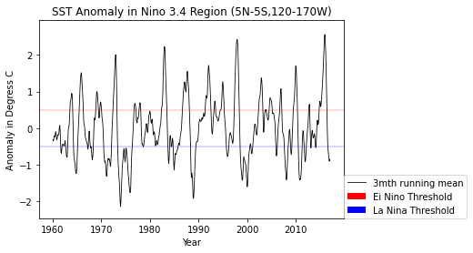

```python
def smooth(x,width):#求窗口为3的滑动平均值
    out0 = np.convolve(x,np.ones(width,dtype=int),'valid')/width
    r = np.arange(1,width-1,2)
    start = np.cumsum(x[:width-1])[::2]/r
    stop = (np.cumsum(x[:-width:-1])[::2]/r)[::-1]
    return np.concatenate(( start , out0, stop ))
ds_nino_anoma_runnningaver = smooth(ds_nino_anoma,3)#滑动窗口得到的均值
a = np.maximum(ds_nino_anoma,0)#将负值全部设为0
b = np.minimum(ds_nino_anoma,0)#将正值全部设为0
X = ds_nino['time']
plt.bar(X,a,width = 150,color = 'r',label='Ei Nino Threshold')
plt.bar(X,b,width = 150,color = 'b',label='La Nina Threshold')
plt.plot(X,ds_nino_anoma_runnningaver,color = 'black',linewidth = 0.8,label='3mth running mean')
plt.axhline(y=0.5, color='r', linestyle='-',alpha=0.2)
plt.axhline(y=-0.5, color='b', linestyle='-',alpha=0.2)
plt.title('SST Anomaly in Nino 3.4 Region (5N-5S,120-170W)')
plt.xlabel('Year')
plt.ylabel('Anomaly in Degress C')
plt.legend(bbox_to_anchor=(1, 0), loc=3, borderaxespad=0)
plt.show()
```

Good but still lack of some colors. No point was deducted.

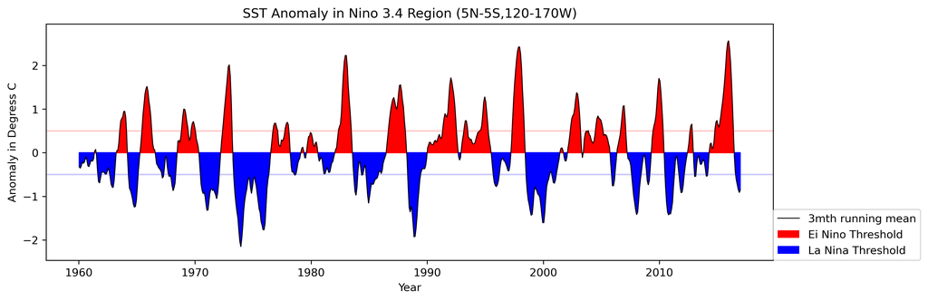

```python
## By HUANG

plt.figure(figsize=(12,4), dpi=300)

plt.bar(X,a,width = 150,color = 'r',label='Ei Nino Threshold')
plt.bar(X,b,width = 150,color = 'b',label='La Nina Threshold')
plt.plot(X,ds_nino_anoma_runnningaver,color = 'black',linewidth = 0.8,label='3mth running mean')
plt.axhline(y=0.5, color='r', linestyle='-',alpha=0.2)
plt.axhline(y=-0.5, color='b', linestyle='-',alpha=0.2)

plt.fill_between(X, 0, ds_nino_anoma_runnningaver, where=(ds_nino_anoma_runnningaver) < 0 , color='blue')
plt.fill_between(X, 0, ds_nino_anoma_runnningaver, where=(ds_nino_anoma_runnningaver) > 0 , color='red')

plt.title('SST Anomaly in Nino 3.4 Region (5N-5S,120-170W)')
plt.xlabel('Year')
plt.ylabel('Anomaly in Degress C')
plt.legend(bbox_to_anchor=(1, 0), loc=3, borderaxespad=0)
plt.show()
```

## 2. Earth’s energy budget (27/30)

1. Earth’s energy budget In this problem set, you will analyze top-of-atmosphere (TOA) radiation data from NASA’s CERES project. Read this post for more about Earth’s energy budget. Download the data (CERES_EBAF-TOA_200003-201701.nc) here. The size of the data file is 702.5 MB. It will take a minute or two to download. Start by importing xarray, numpy, and matplotlib.

**2.1 [5 points] Make a 2D plot of the time-mean TOA longwave, shortwave, and solar radiation for all-sky conditions. Add up the three variables above and verify (visually) that they are equivalent to the TOA net flux.**

**先画出toa_lw月均值图**

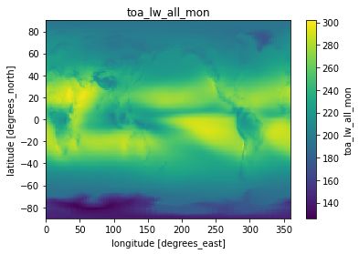

```python
import numpy as np
import pandas as pd
import xarray as xr
from matplotlib import pyplot as plt
ds = xr.open_dataset('CERES_EBAF-TOA_200003-201701.nc', engine="netcdf4")
ds_lw_all = ds.toa_lw_all_mon.mean(dim = ['time'])
ds_sw_all = ds.toa_sw_all_mon.mean(dim = ['time'])
ds_solar = ds.solar_mon.mean(dim = ['time'])
ds_net_all = ds.toa_net_all_mon.mean(dim = ['time'])
ds_sum = ds_solar - ds_lw_all - ds_sw_all
ds_lw_all.plot()
plt.title('toa_lw_all_mon')
```

**再画出toa_sw_all月均值的图**

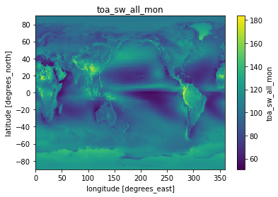

```python
ds_sw_all.plot()
plt.title('toa_sw_all_mon')
```

**再画出太阳辐射的图**

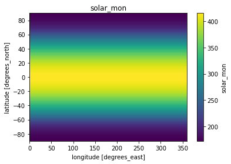

```python
ds_solar.plot()
plt.title('solar_mon')
```

**再画出净通量**

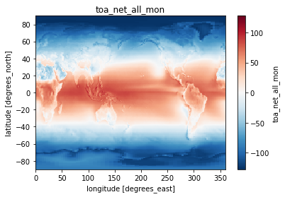

```python
ds_net_all.plot()
plt.title('toa_net_all_mon')
```

**最后画出辐射-长波-短波的值**

**与上图比较从视觉上看出两图基本相同,即验证了上述算式的值等于净通量**

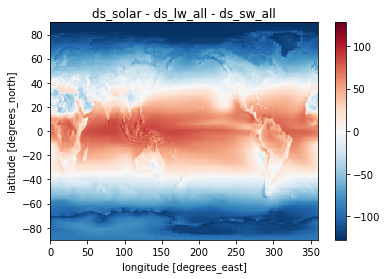

```python
ds_sum.plot()
plt.title('ds_solar - ds_lw_all - ds_sw_all')
```

**2.2 [10 points] Calculate and verify that the TOA incoming solar, outgoing longwave, and outgoing shortwave approximately match up with the cartoon above.**

[Hint: Consider calculating the area of each grid]

得到： **Incoming Solar Flux, Monthly Means = 340.28355233050684**

**Top of The Atmosphere Longwave Flux, Monthly Means, All-Sky conditions = 240.26666558090503**

**Top of The Atmosphere Shortwave Flux, Monthly Means, All-Sky conditions = 99.13858336324701**

**与题目中所给图相比，经过计算后的长波，短波，太阳辐射的值与图中所给的值基本相等**

```python
convert_lat = np.cos(np.deg2rad(ds.lat))
#纬度角度转为弧度值再求cos
toa_solar_plus_weight = ds_solar.weighted(convert_lat)
toa_lw_plus_weight = ds_lw_all.weighted(convert_lat)
toa_sw_plus_weight = ds_sw_all.weighted(convert_lat)
solar_radiation = toa_solar_plus_weight.mean(dim=('lon', 'lat','time')).values
lw_radiation = toa_lw_plus_weight.mean(dim=('lon', 'lat','time')).values
sw_radiation = toa_sw_plus_weight.mean(dim=('lon', 'lat','time')).values
print('Incoming Solar Flux, Monthly Means = '+str(solar_radiation))
print('Top of The Atmosphere Longwave Flux, Monthly Means, All-Sky conditions = ' + str(lw_radiation))
print('Top of The Atmosphere Shortwave Flux, Monthly Means, All-Sky conditions = ' + str(sw_radiation))
```

[output not shown]

Your code could not work, I modified as follow. 1 point was deducted.

```python
## By HUANG

convert_lat = np.cos(np.deg2rad(ds.lat))
#纬度角度转为弧度值再求cos
toa_solar_plus_weight = ds_solar.weighted(convert_lat)
toa_lw_plus_weight = ds_lw_all.weighted(convert_lat)
toa_sw_plus_weight = ds_sw_all.weighted(convert_lat)
solar_radiation = toa_solar_plus_weight.mean(dim=('lon', 'lat')).values   ###toa_solar_plus_weight has been calculated along time.
lw_radiation = toa_lw_plus_weight.mean(dim=('lon', 'lat')).values
sw_radiation = toa_sw_plus_weight.mean(dim=('lon', 'lat')).values
print('Incoming Solar Flux, Monthly Means = '+str(solar_radiation))
print('Top of The Atmosphere Longwave Flux, Monthly Means, All-Sky conditions = ' + str(lw_radiation))
print('Top of The Atmosphere Shortwave Flux, Monthly Means, All-Sky conditions = ' + str(sw_radiation))
```

```
Incoming Solar Flux, Monthly Means = 340.28355233050684
Top of The Atmosphere Longwave Flux, Monthly Means, All-Sky conditions = 240.26668982116465
Top of The Atmosphere Shortwave Flux, Monthly Means, All-Sky conditions = 99.13859548337682
```

**2.3 [5 points] Calculate and plot the total amount of net radiation in each 1-degree latitude band. Label with correct units.**

**先求每1纬度的值再画图**

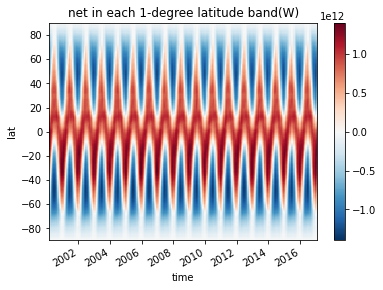

```python
toa_weighted_net =  ds.toa_net_all_mon.weighted(convert_lat)
R=6371.4e3 #地球半径
earth_surface_weighted= 2*np.pi**2*convert_lat*R**2/(180*360)
one_lat_net = toa_weighted_net.mean(dim='lon') * earth_surface_weighted #每1纬度的净通量的均值
one_lat_net.transpose().plot()
plt.title('net in each 1-degree latitude band(W)')
```

It should be sum, not mean. 1 point was deducted.

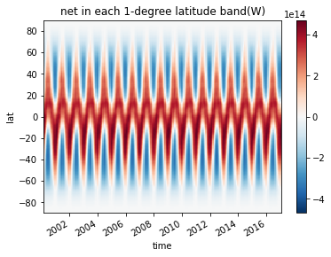

```python
## By HUANG

toa_weighted_net =  ds.toa_net_all_mon.weighted(convert_lat)
R=6371.4e3 #地球半径
earth_surface_weighted= 2*np.pi**2*convert_lat*R**2/(180*360)
one_lat_net = toa_weighted_net.sum(dim='lon') * earth_surface_weighted #每1纬度的净通量的均值
one_lat_net.transpose().plot()
plt.title('net in each 1-degree latitude band(W)')
```

**2.4 [5 points] Calculate and plot composites of time-mean outgoing shortwave and longwave radiation for low and high cloud area regions. Here we define low cloud area as ≤25% and high cloud area as ≥75%. Your results should be 2D maps.**

**先将低云和高云域分开，再运用where分开数据，然后作图**

**先画高云域长波**

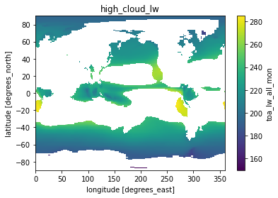

```python
cloud = ds.cldarea_total_daynight_mon.mean('time').values
high_cloud_area = cloud > 75#将>75的值判定为高云域，输出为布尔矩阵
low_cloud_area = cloud < 25 #将<25的值判定为低云域,输出为布尔矩阵
high_cloud_lw = ds_lw_all.where(high_cloud_area)
high_cloud_lw.plot()
plt.title('high_cloud_lw')#高云域长波
```

**再画低云域长波**

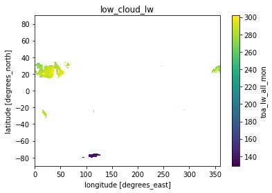

```python
low_cloud_lw = ds_lw_all.where(low_cloud_area)
low_cloud_lw.plot()
plt.title('low_cloud_lw')#低云域长波
```

**再画高云域短波**

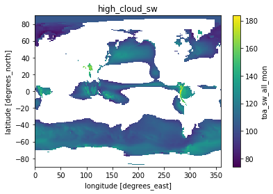

```python
high_cloud_sw = ds_sw_all.where(high_cloud_area)
high_cloud_sw.plot()
plt.title('high_cloud_sw')#高云域短波
```

**再画低云域短波**

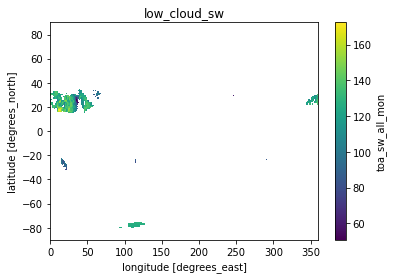

```python
low_cloud_sw = ds_sw_all.where(low_cloud_area)
low_cloud_sw.plot()
plt.title('low_cloud_sw')#低云域短波
```

After our three TAs discussed about question 2.4 and 2.5. We think that's more proper to select radiation by cloud condition and then calculate mean values. That's because radiation values are affected by cloud condition at that moment, not by the mean conditions. So, 1 point was deducted. And I also modified your code as follow, please think more.

```python
## By HUANG Hao
# Create Figure and Subplots
fig,axes = plt.subplots(2,2,figsize=(16,8),dpi=500)
# Plot each axes
ds.toa_lw_all_mon.where(ds.cldarea_total_daynight_mon >= 75).mean(dim='time').plot(ax=axes[0,0])
ds.toa_sw_all_mon.where(ds.cldarea_total_daynight_mon >= 75).mean(dim='time').plot(ax=axes[0,1])
ds.toa_lw_all_mon.where(ds.cldarea_total_daynight_mon <= 25).mean(dim='time').plot(ax=axes[1,0])
ds.toa_sw_all_mon.where(ds.cldarea_total_daynight_mon <= 25).mean(dim='time').plot(ax=axes[1,1])
axes[0,0].set_title('high cloud area outgoing longwave',fontsize = 14)
axes[0,1].set_title('high cloud area outgoing shortwave',fontsize = 14)
axes[1,0].set_title('low cloud area outgoing longwave',fontsize = 14)
axes[1,1].set_title('low cloud area outgoing shortwave',fontsize = 14)
plt.tight_layout()
```

[figure not shown]

**2.5 [5 points] Calculate the global mean values of shortwave and longwave radiation, composited in high and low cloud regions. What is the overall effect of clouds on shortwave and longwave radiation?**

```python
high_cloud_global_lw_mean = high_cloud_lw.mean(dim = ['lat','lon'])
low_cloud_global_lw_mean = low_cloud_lw.mean(dim = ['lat','lon'])
high_cloud_global_sw_mean = high_cloud_sw.mean(dim = ['lat','lon'])
low_cloud_global_sw_mean = low_cloud_sw.mean(dim = ['lat','lon'])
print('high_cloud_global_lw_mean = ' + str(high_cloud_global_lw_mean.values))
print('low_cloud_global_lw_mean = ' + str(low_cloud_global_lw_mean.values))
print('high_cloud_global_sw_mean = ' + str(high_cloud_global_sw_mean.values))
print('low_cloud_global_sw_mean = ' + str(low_cloud_global_sw_mean.values))
```

```
high_cloud_global_lw_mean = 216.55675
low_cloud_global_lw_mean = 270.10367
high_cloud_global_sw_mean = 108.09777
low_cloud_global_sw_mean = 122.65546
```

其实应该说清楚云对长波和短波分别的影响。多云应该增强短波，弱化长波。

```python
high_cloud_global_lw_mean = ds.toa_lw_all_mon.where(ds.cldarea_total_daynight_mon >= 75).mean(dim='time').mean(dim = ['lat','lon'])
low_cloud_global_lw_mean = ds.toa_lw_all_mon.where(ds.cldarea_total_daynight_mon <= 25).mean(dim='time').mean(dim = ['lat','lon'])
high_cloud_global_sw_mean = ds.toa_sw_all_mon.where(ds.cldarea_total_daynight_mon >= 75).mean(dim='time').mean(dim = ['lat','lon'])
low_cloud_global_sw_mean = ds.toa_sw_all_mon.where(ds.cldarea_total_daynight_mon <= 25).mean(dim='time').mean(dim = ['lat','lon'])
print('high_cloud_global_lw_mean = ' + str(high_cloud_global_lw_mean.values))
print('low_cloud_global_lw_mean = ' + str(low_cloud_global_lw_mean.values))
print('high_cloud_global_sw_mean = ' + str(high_cloud_global_sw_mean.values))
print('low_cloud_global_sw_mean = ' + str(low_cloud_global_sw_mean.values))
```

```
high_cloud_global_lw_mean = 215.37349
low_cloud_global_lw_mean = 233.06702
high_cloud_global_sw_mean = 114.74328
low_cloud_global_sw_mean = 88.81645
```

## 3. Explore a netCDF dataset （10/10）

3. Explore a netCDF dataset Browse the NASA’s Goddard Earth Sciences Data and Information Services Center (GES DISC) website. Search and download a dataset you are interested in. You are also welcome to use data from your group in this problem set. But the dataset should be in netCDF format, and have temporal information.

**3.1 [5 points] Plot a time series of a certain variable with monthly seasonal cycle removed.**

**先画出每月的均值**

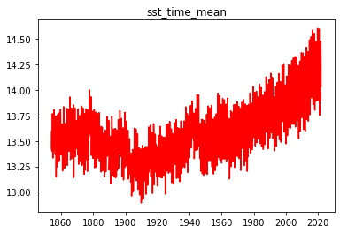

```python
import numpy as np
import pandas as pd
import xarray as xr
from matplotlib import pyplot as plt
ds_3 = xr.open_dataset('sst.mnmean.nc', engine="netcdf4")
ds_sst = ds_3.sst.mean(dim = ['lat','lon'])
X = ds_sst['time'].values
plt.plot(X,ds_sst,color = 'r')
plt.title('sst_time_mean')
```

**3.2 [5 points] Make at least 5 different plots using the dataset.**

**画出全世界的均值**

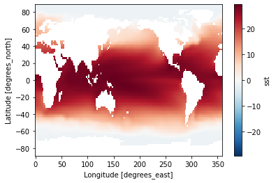

```python
ds_time = ds_3.sst.mean(dim = ['time'])
ds_time.plot()
```

**画出北半球的均值**

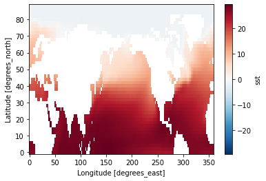

```python
north = ds_3.sst.sel(lat = slice(88,0))
ds_north = north.mean(dim = ['time'])
ds_north.plot()
```

**画出南半球的均值**

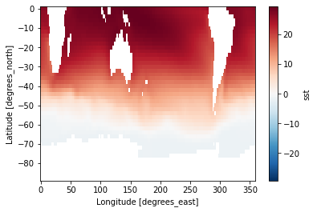

```python
south = ds_3.sst.sel(lat = slice(0,-88))
ds_south = south.mean(dim = ['time'])
ds_south.plot()
```

**画出中国的均值**

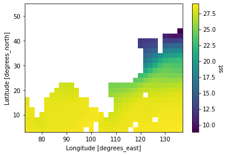

```python
china = ds_3.sst.sel(lat = slice(54,3),lon = slice(73,136))
ds_china = china.mean(dim = ['time'])
ds_china.plot()
```

**画出美国的均值**

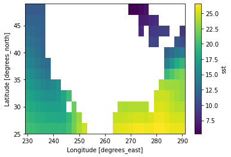

```python
america = ds_3.sst.sel(lat = slice(49,25),lon = slice(230,290))
ds_america = america.mean(dim = ['time'])
ds_america.plot()
```

**画出俄罗斯的均值**

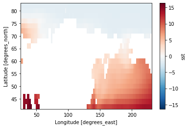

```python
russia = ds_3.sst.sel(lat = slice(82,41),lon = slice(26,230))
ds_russia = russia.mean(dim = ['time'])
ds_russia.plot()
```